# Sprawozdanie - Zadanie 4

Paulina Popiołek, Agnieszka Pszczółkowska

20 kwietnia 2017

# 1. Cel zadania

Celem zadania jest wyznaczenie na podstawie dotychczasowych badań różnych strategii w rozwiązywaniu zadań i porównanie pod tym kątem krajów oraz szkół, które wzięły udział w badaniu.

# 2. Dane

Studentów postanowiłyśmy podzielić na 4 grupy ze względu na średni czas rozwiązywania zadań na pozycji 1 oraz 4. Średnie czasy rozwiązywania zadań na poszczególnych pozycjach, jakie posiadał dany student, porównałyśmy z ważonymi średnimi czasami wszystkich uczniów na tych pozycjach. Wynikowy zbiór ma następującą postać.

| CNTSTUID | CNT | CNTSCHID | W_FSTUWT | segment | position | meanTimingStudent |
| --- | --- | --- | --- | --- | --- | --- |
| 3600009 | AUS | 3600365 | 26.45644 | wolno_wolno | 1 | 95.25 |
| 3600013 | AUS | 3600236 | 9.00075 | wolno_wolno | 1 | 88.47 |
| 3600079 | AUS | 3600360 | 27.94818 | wolno_wolno | 1 | 88.72 |
| 3600080 | AUS | 3600372 | 3.77276 | wolno_wolno | 1 | 112.49 |
| 3600081 | AUS | 3600285 | 4.52912 | wolno_wolno | 1 | 162.32 |

# 3. Wnioski

1. Uczniowie krajów azjatyckich - Hongkongu i Korei - mają takie same strategie: zaczynają rozwiązywać test szybko i szybko go kończą. Warto przy tym wspomnieć, że kraje te znajdują się w czołówce rankingu PISA 2015.
2. Kraje będące nisko w rankingu - Brazylia, Peru, Meksyk - charakteryzują się wolnym rozwiązywaniem całego testu.
3. Zaskakujące podobieństwo w stosowanych strategiach występuje wśród uczniów wydawałoby się różnych krajów: Wielkiej Brytanii i Japonii. W obu tych krajach procenty uczniów stosujących odpowiednie strategie są bardzo do siebie zbliżone.
4. Uczniowie z Polski raczej zaczynają rozwiązywać zadania szybko, jednak zróżnicowanie pomiędzy procentem uczniów stosujących poszczególne strategie nie jest aż tak duże, jak w krajach azjatyckich.
5. Strategie szkół nie muszą być zgodne z ogólnymi trendami w danym kraju, np. w Polsce są szkoły, w których uczniowie rozwiązują test zaczynając szybko i szybko kończąc, ale są też takie, które raczej stosują strategię wolnego początku i końca, co jest odmienne od ogólnych spostrzeżeń dla strategii w kraju.

# 4. Analiza

Analizę zaczęłyśmy od porównania rozkładów średniego czasu rozwiązywania zadań w zależności od pozycji zadania w arkuszu w podziale na wyznaczone segmenty.

W kolejnych punktach analizy, wizualizacje zostały wykonane dla wybranej grupy krajów. Są to: 1. Polska 2. Finlandia 3. Niemcy 4. Czechy 5. Włochy 6. Wielka Brytania 7. USA 8. Kanada 9. Japonia 10. Korea 11. Hong Kong 12. Peru 13. Brazylia 14. Meksyk 15. Austalia

## 4.1 Jak wygląda rozkład średniego czasu odpowiedzi na poszczególnych pozycjach dla czterech strategii?

Po dokonaniu podziału studentów ze względu na zdefiniowane przez nas strategie, wyliczyłyśmy podobnie jak w poprzednich analizach średnie ważone dla poszczególnych państw z podziałem na segment i pozycję. Tak zebrane wyniki umieściłyśmy na wykresie poniżej.

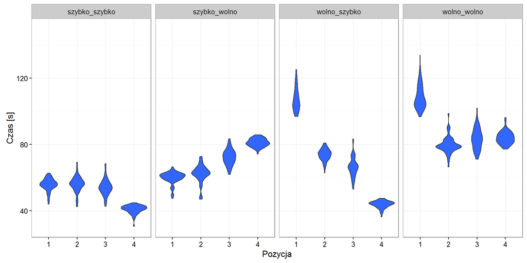

Powyższe wykresy pozwalają na bardziej szczegółowy opis strategii przez nas wyznaczonych:

- szybko_szybko - strategia polegająca na szybkim rozwiązywaniu całego testu (w szczególności zadań na pozycji 1 i 4),
- szybko_wolno - strategia, w której uczniowie zaczynają szybko rozwiązywać zadania znajdujące się na pozycji 1, a na kolejne zadania poświęcają coraz więcej czasu,
- wolno_szybko - strategia polegająca na długim rozwiązywaniu początkowych zadań i znaczącym przyspieszeniu pod koniec testu,
- wolno_wolno - strategia, w której wszystkie zadania są rozwiązywane w dość długim czasie.

## 4.2 Jakie strategie stosują uczniowie w różnych krajach?

Do tej pory interesowały nas nas różnice między krajami w średnich czasach odpowiedzi. Teraz ważną kwestią może się okazać zróżnicowanie ze względu na stosowaną przez uczniów strategię. W tym celu wyznaczyłyśmy procent uczniów z wybranych krajów stosujących zdefiniowane przez nas sposoby rozwiązywania testu.

[interactive chart not shown]

Różnice w krzywych dla Hong Kongu i Korei są nieznaczne. Co ciekawe, względem pierwszej strategii, tuż za nimi znajduje się Japonia. Ponieważ kraje te od lat znajdują się w czołówce rankingu PISA, wydaje się, że poza dobrym przygotowaniem, również szybkie rozwiązywanie zadań jest kluczem do sukcesu.  
Po drugiej stronie wykresu wyraźnie dominują państwa Ameryki Południowej - tutaj największy udział stanowią uczniowie, który wolno rozwiązują wszystkie zadania. One z kolei zajmują niskie miejsca w rankingach - być może punkty uciekają im na zadaniach, których nie zdążą rozwiązać, tracąc czas na tych, których i tak nie potrafią zrobić. Duże podobieństwo między stosowanymi strategiami widać także na przykładzie par: Niemcy - Finlandia oraz Wielka Brytania - Japonia. O ile pierwsze dwa państwa są do siebie podobne ze względu na położenie geograficzne czy względy polityczne, tak drugie wymienione podobieństwo jest zaskakujące.

Różnice w sposobach rozwiązywania zadań między krajami przedstawiają też poniższe wykresy - widać tu wyraźny trend szybkiego rozwiązywania testu wśród uczniów z Hongkongu, wolnego rozwiązywania w Brazylii oraz różnie wybieranych strategii w Polsce.

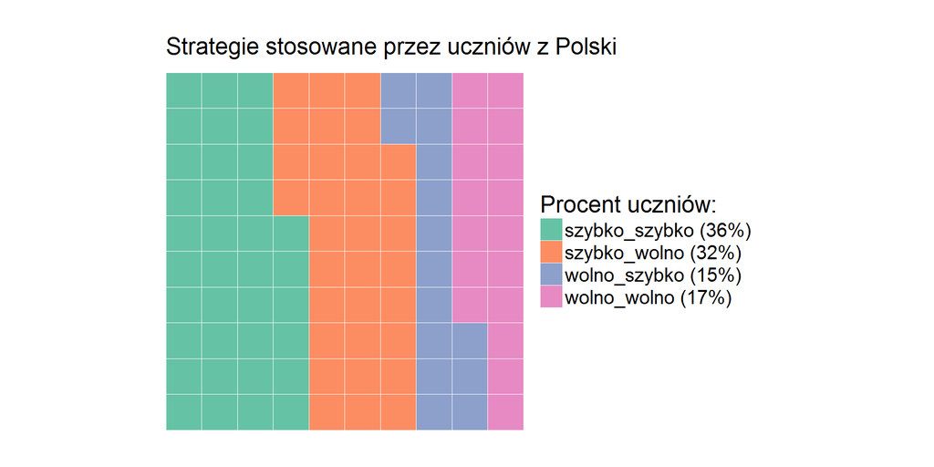

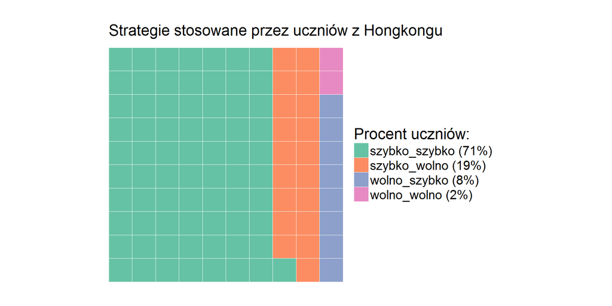

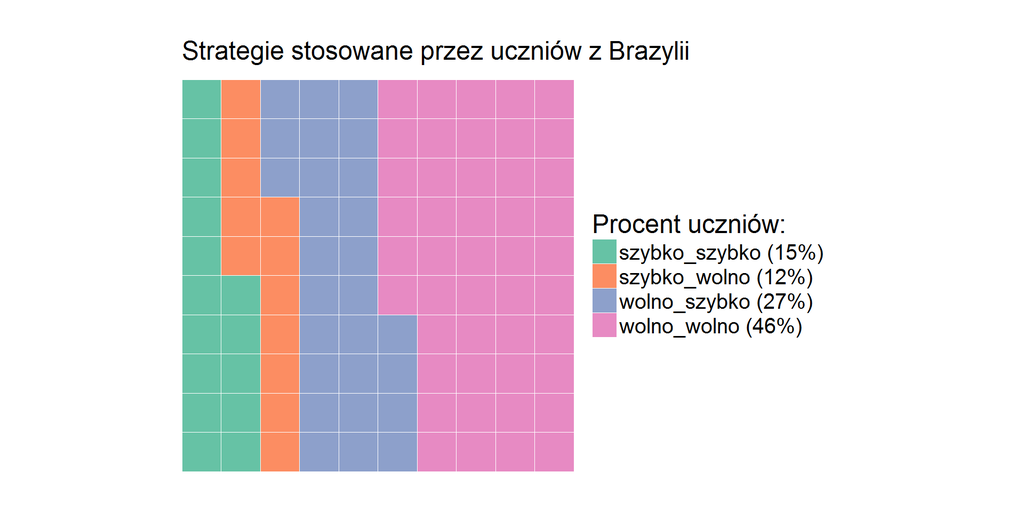

# 4.3 Czy szkoła ma znaczenie ?

W powyższej analizie możemy zejść o poziom niżej, wówczas dodatkowym czynnikiem będzie szkoła. Wybrałyśmy dwie szkoły z Polski obrazujące to, jak dużą rolę w wyborze strategii przy rozwiązywaniu zadań może mieć szkoła.

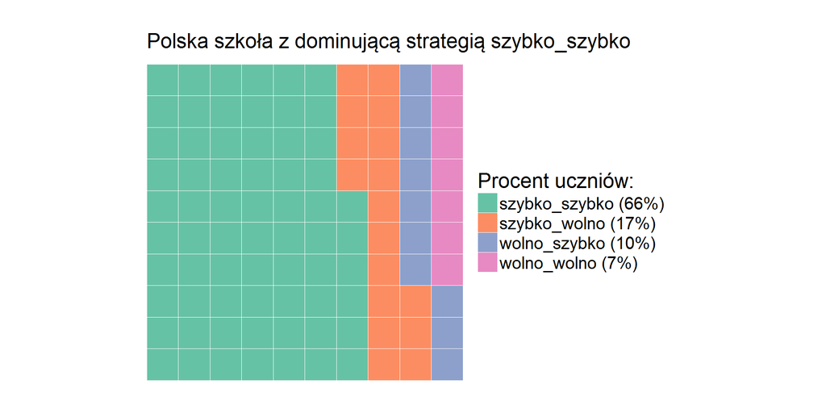

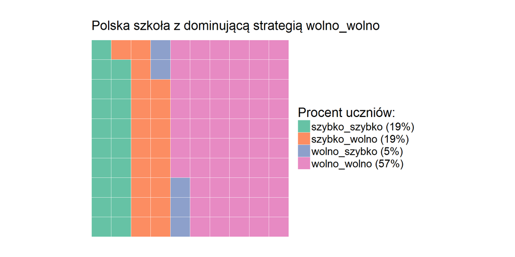

# 5. Wykonany kod

```r
library("dplyr")
library("stringi")
library("tidyr")
library("ggplot2")
library("plotly")
library("waffle")

load("finalS.RData")
load("finalMR.RData")
colnames(finalS)[14]<-"result"
data<-rbind(finalS, finalMR)

data<-data %>% mutate(exercise=stri_sub(item_short, 1,1), timing=timing/1000) %>%
                mutate_if(is.factor, as.character)%>% mutate(CNT=stri_trim(CNT))

data$result<-ifelse(data$result=="No credit", 0, ifelse(data$result=="Partial credit", 1,2))

# Granice - średnie ważone z czasów na poszczególnych pozycjach
granice<-data %>% group_by(position) %>% summarize(limit=round(weighted.mean(timing, W_FSTUWT),2))

# Średnie ważone studentów na poszczególnych pozycjach
data2<-data%>%group_by(CNTSTUID, position)%>%
  summarize(meanTimingStudent=round(weighted.mean(timing, W_FSTUWT),2)) %>%
  spread(position,meanTimingStudent)

data2<-na.omit(data2)

# Podział na grupy
wolno_wolno<-data2[data2$`1`>granice$limit[1] & data2$`4`>granice$limit[4],]
wolno_szybko<-data2[data2$`1`>granice$limit[1] & data2$`4`<=granice$limit[4],]
szybko_wolno<-data2[data2$`1`<=granice$limit[1] & data2$`4`>granice$limit[4],]
szybko_szybko<-data2[data2$`1`<=granice$limit[1] & data2$`4`<=granice$limit[4],]


load("stud.RData")

wolno_wolno_merge<- merge(wolno_wolno, stud[,c(1:3,10)], by="CNTSTUID", all.x=TRUE)
wolno_szybko_merge<- merge(wolno_szybko, stud[,c(1:3,10)], by="CNTSTUID", all.x=TRUE)
szybko_wolno_merge<- merge(szybko_wolno, stud[,c(1:3,10)], by="CNTSTUID", all.x=TRUE)
szybko_szybko_merge<- merge(szybko_szybko, stud[,c(1:3,10)], by="CNTSTUID", all.x=TRUE)

wolno_wolno_merge<-wolno_wolno_merge %>% mutate(segment="wolno_wolno")
wolno_szybko_merge<-wolno_szybko_merge %>% mutate(segment="wolno_szybko")
szybko_wolno_merge<-szybko_wolno_merge %>% mutate(segment="szybko_wolno")
szybko_szybko_merge<-szybko_szybko_merge %>% mutate(segment="szybko_szybko")

dane <- rbind(wolno_wolno_merge,wolno_szybko_merge,szybko_wolno_merge,szybko_szybko_merge)

dane1<-gather(dane, key=position, value=meanTimingStudent, 2:5 )


###################################################
# WYKRESY
###################################################


# WYKRES I

dane2<-dane1 %>% group_by(CNT, segment, position) %>%
              summarize(meanTiming=round(weighted.mean(meanTimingStudent, W_FSTUWT),2))


ggplot(dane2, aes(x=factor(position), y=meanTiming))+
  geom_violin(fill="#3366FF")+
  facet_grid(.~segment)+
  xlab("Pozycja")+
  ylab("Czas [s]")+
  theme_bw()+
  ylim(c(30,150))

# WYKRES II

# wyznaczenie liczby studentów w poszczególnych krajach stosujących konkretne strategie
dane3<-dane1 %>% group_by(CNT, segment) %>% summarize(liczbaStudentow=n())

dane3<-dane3 %>% group_by(CNT) %>% mutate(procentStudentow=100*liczbaStudentow/sum(liczbaStudentow))

rank1<-dane3 %>% filter(segment=="szybko_szybko") %>% select(segment, CNT, procentStudentow)
rank1<-rank1[order(rank1$procentStudentow, decreasing = T),]

rank2<-dane3 %>% filter(segment=="szybko_wolno") %>% select(segment, CNT, procentStudentow)
rank2<-rank2[order(rank2$procentStudentow, decreasing = T),]

rank3<-dane3 %>% filter(segment=="wolno_szybko") %>% select(segment, CNT, procentStudentow)
rank3<-rank3[order(rank3$procentStudentow, decreasing = T),]

rank4<-dane3 %>% filter(segment=="wolno_wolno") %>% select(segment, CNT, procentStudentow)
rank4<-rank4[order(rank4$procentStudentow, decreasing = T),]

rank<-rbind(rank1, rank2, rank3, rank4)


#wybieramy kraje, które wcześniej rozważaliśmy
rank <- rank %>% ungroup() %>%  mutate_if(is.factor, as.character) %>% mutate(CNT=stri_trim(CNT)) %>%
  filter(CNT %in% c("POL", "GBR", "FIN", "DEU", "HKG", "JPN", "KOR", "USA", "MEX", "PER", "BRA", "CAN", "AUS", "ITA","CZE") )


g<-ggplot(rank, aes(x=segment,y=procentStudentow, color=CNT, group=CNT)) +
  geom_point(size=3)+
  geom_path(size=1)+
  ggtitle("Jakie strategie stosują uczniowie w różnych krajach?")+
  ylab("Procent uczniów")+
  xlab("")+
  theme_bw()+
  guides(color=guide_legend("Kraj"))+
  scale_x_discrete(expand=c(0.01, 0))+
  scale_y_continuous(expand=c(0, 0), limits=c(0,100),
                     labels=c(paste(0, "%"), paste(25, "%"), paste(50, "%"), paste(75, "%"), paste(100, "%")))

g %>% ggplotly(originalData = FALSE, legend=FALSE)

#WYKRES III

#POLSKA
danePOL<-dane3 %>% ungroup() %>%  mutate_if(is.factor, as.character) %>%
                   mutate(CNT=stri_trim(CNT))%>% filter(CNT=="POL")  %>%
                   mutate(procentStudentow=100*liczbaStudentow/sum(liczbaStudentow))
danePOL1<-c("szybko_szybko (36%)"=36,"szybko_wolno (32%)"=32,"wolno_szybko (15%)"=15 , "wolno_wolno (17%)"=17 )

w<-waffle(danePOL1, rows=10, size=0)
w+ggtitle("Strategie stosowane przez uczniów z Polski")+
  theme(plot.title=element_text(margin=margin(b=0.5, unit="cm"),hjust=0, size=18),
        legend.title = element_text(size=18),
        legend.text = element_text(size = 15),
        plot.margin=unit(c(1,1,1,1), "cm"))+
  guides(fill=guide_legend(title="Procent uczniów:"))

#HONGKONG
daneHKG<-dane3 %>% ungroup() %>%  mutate_if(is.factor, as.character) %>%
  mutate(CNT=stri_trim(CNT))%>% filter(CNT=="HKG")  %>%
  mutate(procentStudentow=100*liczbaStudentow/sum(liczbaStudentow))
daneHKG1<-c("szybko_szybko (71%)"=71,"szybko_wolno (19%)"=19,"wolno_szybko (8%)"=8 , "wolno_wolno (2%)"=2 )

w<-waffle(daneHKG1, rows=10, size=0)
w+ggtitle("Strategie stosowane przez uczniów z Hongkongu")+
  theme(plot.title=element_text(margin=margin(b=0.5, unit="cm"),hjust=0, size=18),
        legend.title = element_text(size=18),
        legend.text = element_text(size = 15),
        plot.margin=unit(c(1,1,1,1), "cm"))+
  guides(fill=guide_legend(title="Procent uczniów:"))

#BRAZYLIA
daneBRA<-dane3 %>% ungroup() %>%  mutate_if(is.factor, as.character) %>%
  mutate(CNT=stri_trim(CNT))%>% filter(CNT=="BRA")  %>%
  mutate(procentStudentow=100*liczbaStudentow/sum(liczbaStudentow))
daneBRA1<-c("szybko_szybko (15%)"=15,"szybko_wolno (12%)"=12,"wolno_szybko (27%)"=27 , "wolno_wolno (46%)"=46 )

w<-waffle(daneBRA1, rows=10, size=0)
w+ggtitle("Strategie stosowane przez uczniów z Brazylii")+
  theme(plot.title=element_text(margin=margin(b=0.5, unit="cm"),hjust=0, size=18),
        legend.title = element_text(size=18),
        legend.text = element_text(size = 15),
        plot.margin=unit(c(1,1,1,1), "cm"))+
  guides(fill=guide_legend(title="Procent uczniów:"))

#WYKRES IV
dane1<-dane1 %>% mutate(CNT=stri_trim(CNT))
dane4<-dane1 %>% filter(CNT=="POL")%>% group_by(CNTSCHID, segment) %>% summarize(liczbaStudentow=n())

dane4<-dane4 %>% group_by(CNTSCHID) %>% mutate(procentStudentow=100*liczbaStudentow/sum(liczbaStudentow))

daneSzkola1<-dane4 %>% filter(CNTSCHID==61600025)
daneSzkola1a<-c("szybko_szybko (66%)"=66,"szybko_wolno (17%)"=17,"wolno_szybko (10%)"=10 , "wolno_wolno (7%)"=7 )
w<-waffle(daneSzkola1a, rows=10, size=0)
w+ggtitle("Polska szkoła z dominującą strategią szybko_szybko")+
  theme(plot.title=element_text(margin=margin(b=0.5, unit="cm"),hjust=0, size=18),
        legend.title = element_text(size=18),
        legend.text = element_text(size = 15),
        plot.margin=unit(c(1,1,1,1), "cm"))+
  guides(fill=guide_legend(title="Procent uczniów:"))

daneSzkola2<-dane4 %>% filter(CNTSCHID==61600024)
daneSzkola2a<-c("szybko_szybko (19%)"=19,"szybko_wolno (19%)"=19,"wolno_szybko (5%)"=5 , "wolno_wolno (57%)"=57 )
w<-waffle(daneSzkola2a, rows=10, size=0)
w+ggtitle("Polska szkoła z dominującą strategią wolno_wolno")+
  theme(plot.title=element_text(margin=margin(b=0.5, unit="cm"),hjust=0, size=18),
        legend.title = element_text(size=18),
        legend.text = element_text(size = 15),
        plot.margin=unit(c(1,1,1,1), "cm"))+
  guides(fill=guide_legend(title="Procent uczniów:"))
```